# Chi Squared Test

## Background

```r
library(haven)
library(dplyr)
library(ggplot2)
library(reshape2)
library(pander)
library(tidyverse)
library(data.table)

gss2021 <- read_sas("../../Data/gss2021.sas7bdat",
                    NULL)

gss <- gss2021 %>%
  filter(LIFE %in% c(1:3)) %>%
  filter(DEGREE %in% c(0:4)) %>%
  mutate(
    life = case_when(
      LIFE == 1 ~ "1-Exciting",
      LIFE == 2 ~ "2-Routine",
      LIFE == 3 ~ "3-Dull"
    ),
    degree = case_when(
      DEGREE == 0 ~ "0-Dropout",
      DEGREE == 1 ~ "1-High school",
      DEGREE == 2 ~ "2-Associate's",
      DEGREE == 3 ~ "3-Bachelor's",
      DEGREE == 4 ~ "4-Graduate"
    )
  ) %>% select(life, degree)
```

## Questions & Hypotheses

There are a few different questions that could be asked to these data. To show several examples of how a chi-squared test could be implemented, each of the following question will be answered with a chi-squared test.

Is educational level associated with outlook on life?

$$H_{0}:\ \text{Outlook on life and education level are not associated}$$
$$H_{a}:\ \text{Outlook on life and education level are associated}$$

## Data Analysis

```r
# Test H_{01}:
detable <- table(gss$degree, gss$life)
degree.chi <- chisq.test(detable)
degree.chi %>% pander()
```

Pearson’s Chi-squared test: `detable`

| Test statistic | df | P value |
| --- | --- | --- |
| 69.36 | 8 | 6.58e-12 * * * |

As we can see above the degrees of freedom is 8 and the p-value $(p= 6.58e-12)$ which is below our alpha level $( \alpha = 0.05)$ showing that there is a significant difference in the expected values and the observed values.

```r
degree.chi$expected %>% pander()
```

|  | 1-Exciting | 2-Routine | 3-Dull |
| --- | --- | --- | --- |
| **0-Dropout** | 57.11 | 92.97 | 7.921 |
| **1-High school** | 374.5 | 609.6 | 51.94 |
| **2-Associate’s** | 90.01 | 146.5 | 12.48 |
| **3-Bachelor’s** | 253.8 | 413.1 | 35.19 |
| **4-Graduate** | 183.6 | 298.9 | 25.47 |

All expected counts are greater than 5, so the requirements are met. (If this failed, it will still be appropriate as long as all expected counts are at least 1 and the average expected count is at least 5.)

## Graphics

### Residual Heat Map

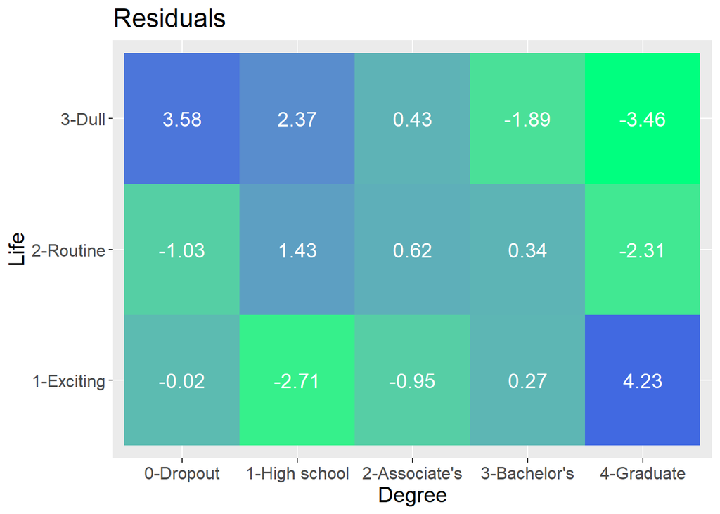

```r
reside <- degree.chi$residuals
heat <- melt(reside)
heat <- setNames(heat, c("Degree", "Life", "Residuals"))
heat <- heat %>%
  mutate(Residuals = round(Residuals,2))

ggplot(heat, aes(x = Degree, y = Life, fill = Residuals)) +
  geom_tile() +
  scale_fill_gradient(low = "springgreen",
                      high = "royalblue",
                      guide = "none") +
  theme(text = element_text(size = 15)) +
  geom_text(aes(label = Residuals), color = "white", size = 5) +
  labs(title="Residuals")
```

We can look at the residuals heat map above to determine which values are not consistent with the expected values, this shows us where there seems to be a relationship between different aspects. In the heat map we can see that the “spring green” colored blocks are at the low end, while the “royal blue” blocks are at the higher end. These color allows us to possibly interpret the residuals matrix with ease and determine possible patterns. In the table above we can observe that the darkest blocks are those at the intersection of **“Dropout” & “Dull”** as well as that of **“Exciting” & “Graduate”**. From this we can create the assumptions that high school dropouts tend to think their life is dull and people with graduate degree’s tend to think of their life as exciting. Even so we can see that there is a darker channel between these two dark blue blocks, showing a sort of correlation if you will that can be interpreted to tell us that the more education you have the more likely you are to view your life as exciting or vice versa, it could say that people who view their life as more exciting will be more likely to get further education.

### Barplot

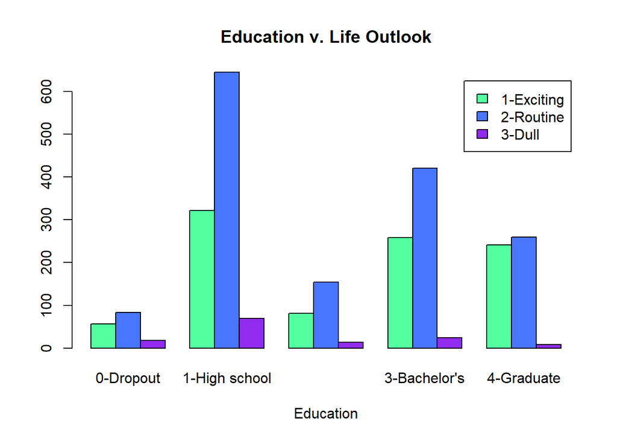

```r
barplot(t(detable), beside=TRUE, legend.text=TRUE, xlab="Education", main="Education v. Life Outlook", col= c("seagreen1","royalblue1", "purple2"))
```

The Chi-squared test above showed a significant relationship exists between education level and outlook on life $(p= 6.58e-12)$. This is seen in the above plot by noting that the pattern of heights on the bars is changed across the different level of education. We can see by looking at the bar plots in the **Dropout** category there seems to be low levels of excitement or routine as compared to the levels of those in Bachelors and Graduate Degrees as where the people who graduate high school have a large proportion of people that say their life feels routine.